# Forschungspraktikum 1+2: Computational Social Science

Session 08: Advanced Topic Modeling

Dr. Christian Czymara

## Agenda

- Advancements of topic models
  - Biterm Topic Models
  - Keyword Assisted Topic Models
  - BERTopic Models
- Chosing the right method
- Tutorial: Identifying keyword topics in news articles

## Recap: Topic Models

- Inductive approach to identify word clusters in texts (topics)
- Suited for explorative research questions
- *But*
  - What if texts are short?
  - Do you really have *no* prior knowledge on the subject before running your model?

## Topic Modelling Tools in R

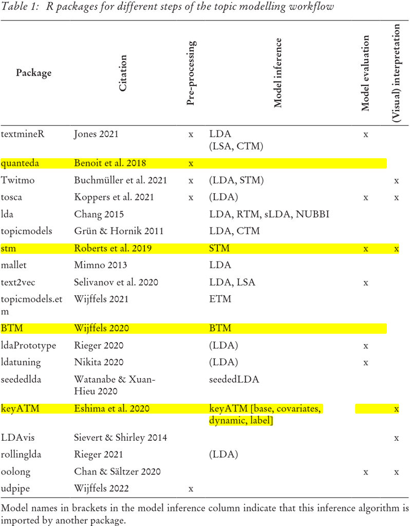

[Wiedemann (2022)](https://doi.org/10.5771/1615-634X-2022-3-286): 288

# Biterm Topic Models (BTM)

## Biterm Topic Models

- Short texts (e.g., tweets) have limited word co-occurrences, making traditional topic models like LDA less effective
- *Biterm Topic Models* (BTM) model word co-occurrence patterns (biterms) across the corpus, not within individual documents
- `BTM` package for R by [Wijffels (2023)](https://cran.r-project.org/web/packages/BTM/BTM.pdf)
- Automatically creates “garbage” topic (reduces preprocessing)

## What Are Biterms?

- A biterm is an unordered pair of words $(w_i, w_j)$ from a document
- Example: “data science tools”
  - $(data, science)$
  - $(data, tools)$
  - $(science, tools)$

## Example Data: Trump (and others) on Twitter

- Combination of two data files: A sample from [Trump Twitter Archive](https://www.thetrumparchive.com/) and a sample from the [sentiment140](https://github.com/okugami79/sentiment140/tree/master/data), 519 observations each.
- Mean number of characters in Tweets: 110 (standard deviation: 56)

## Preprocessing the Data

```r
library(tidyr)

# convert to data.frame
toks_2 <- convert(dfm_tweets, to = "data.frame")
toks_2 <- toks_2 %>%
  pivot_longer(cols = c(!doc_id), names_to = "tokens")

toks_2 <- toks_2[toks_2$value > 0, ]
toks_2 <- toks_2[, c("doc_id", "tokens")]

head(toks_2)
```

```
# A tibble: 6 × 2
  doc_id tokens
  <chr>  <chr>
1 text1  bleh
2 text1  feeling
3 text2  gonna
4 text2  bangerz
5 text2  close
6 text2  feel
```

## Run the BTM

- `k`: Number of topics (20)
- `background`: Background topic (filters common words)

```r
library(BTM)
k <- 20
set.seed(1234)
bi_topics  <- BTM(toks_2,
                  k = k,
                  background = TRUE
                  )

terms(bi_topics, top_n = 10)
```

```
[[1]]
              token probability
1  @realdonaldtrump  0.04075617
2         #ausvotes  0.01026527
3             #swag  0.01026527
4            #vomit  0.01026527
5       @danscavino  0.01026527
6       @dcexaminer  0.01026527
7  @gemmaannestyles  0.01026527
8    @jessicaaaboyd  0.01026527
9       @just_brash  0.01026527
10       @kathviner  0.01026527

[[2]]
            token probability
```

[output cut: 244 more lines]

## Plot the BTM Results

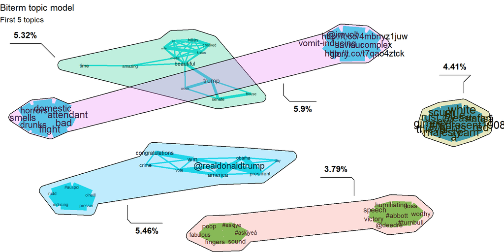

```r
library(textplot)
plot(bi_topics, which = 2:6, subtitle = "First 5 topics",
    labels = paste(round(bi_topics$theta*100, 2), "%", sep = ""), top_n = 15)
```

# Keyword Assisted Topic Models (keyATM)

## Keyword Assisted Topic Models

- Combines supervised and unsupervised approaches
- Allows adding keywords to label topics *prior* to fitting the model (adding domain knowledge)
- Semisupervised model that combines a small amount of information with a large amount of unlabeled data
- `keyATM` package for R by [Eshima et al. (2023)](https://onlinelibrary.wiley.com/doi/10.1111/ajps.12779)

## Example: Immigration in Swedish Newspapers 1945–2019

- Bodell et al. (2024). [Seeded Topic Models in Digital Archives: Analyzing Interpretations of Immigration in Swedish Newspapers, 1945–2019](https://journals.sagepub.com/doi/full/10.1177/00491241241268453). *Sociological Methods & Research*.
- *“In practice, scholars often want to take advantage of the exploratory capabilities of topic models, while also hoping that the models will capture themes that are presumed a priori to exist in a corpus.”*

## Define the Keywords

- Simple example: Just one keyword topic (*Trump*)

```r
keywords <- list(
  trump  = c("donald", "trump", "president", "america")
  )
```

## Prepare the Data

```r
library(keyATM)

keyATM_docs <- keyATM_read(texts = dfm_tweets)
```

## Run the Base keyATM Model

```r
key_topics <- keyATM(
  docs              = keyATM_docs,  # text input
  no_keyword_topics = k-1,          # number of topics without keyword topics
  keywords          = keywords,     # keywords
  model             = "base",       # select the model
  options           = list(seed = 1337)
  )
```

## Results

```r
top_words(key_topics)
```

```
            1_trump          Other_1     Other_2  Other_3
1     president [✓] @realdonaldtrump           â   #vomit
2  @realdonaldtrump           coming     victory    video
3         trump [✓]      @whitehouse      speech   abbott
4       america [✓]              sbw        loss @youtube
5            people             live        mind      day
6               job              ads     @deedre     wait
7          election          channel   #turnbull        â
8           country            local humiliating   george
9             obama           season      worthy    candy
10       donald [✓]           highly     #abbott    prank
                  Other_4                Other_5   Other_6     Other_7 Other_8
1                  smells                      â democrats        sick  turkey
2                     bad                  white    people        feel  tweets
3                  flight                complex     don’t      poison   tears
```

[output cut: 40 more lines]

## Plot the Base keyATM Results

```r
plot_topicprop(key_topics, show_topic = 1:5)
```

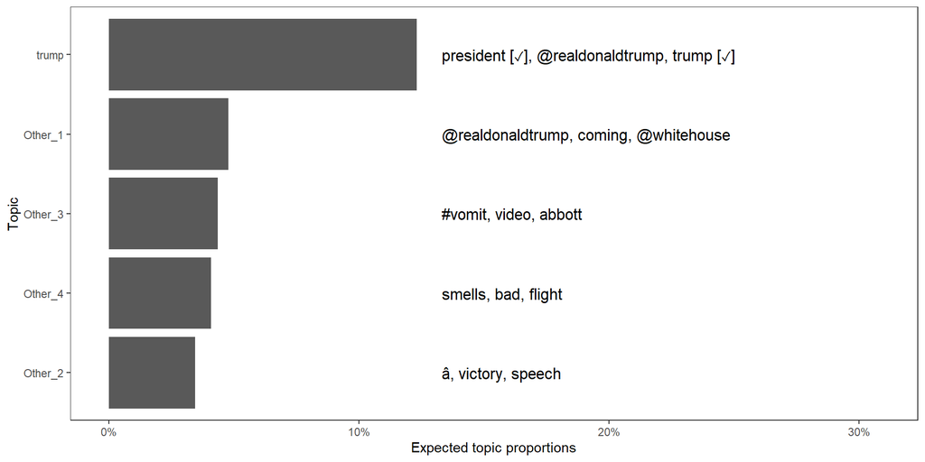

## Example Texts

- Extract the top documents for a given topic to illustrate the results

```r
tweets_combined$text[top_docs(key_topics, 10)[, 1]]
```

```
 [1] "RT @PressSec: President @realDonaldTrump spoke earlier with the @FitnessGov (including @IvankaTrump, Bill Belichick, @MarianoRivera, @Hersc…"
 [2] "Twitter is doing nothing about all of the lies &amp; propaganda being put out by China or the Radical Left Democrat Party. They have targeted Republicans, Conservatives &amp; the President of the United States. Section 230 should be revoked by Congress. Until then, it will be regulated!"
 [3] "RT @dbongino: It’s Wednesday, October 7th 2020, and Barack Obama was DEFINITELY the most corrupt President in US history.\n#Obamagate"
 [4] "\"\"\"@garthdahdah: @TrumpGolfLA [THE] top luxury public golf course in the country http://t.co/MYiwkyfiVU” @realDonaldTrump     Thank you!\""
 [5] "This story is no longer about John McCain, it’s about our horribly treated vets. Illegals are treated better than our wonderful veterans."
 [6] "\"\"\"It's important that we help poor people to become independent, self-sufficient individuals who gain the benefits of work.\"\" #TimeToGetTough\""
 [7] "“Director Brennan’s recent statements purport to know as fact that the Trump campaign colluded with a foreign power. If Director Brennan’s statement is based on intelligence he received while leading the CIA, why didn’t he include it in the Intelligence Community Assessment......"
 [8] "\"\"\"@canoetravel: Plans for wind farm dropped at @realDonaldTrump's #Scotland golf resort: http://t.co/Klaf69uHet #travel #golf\"\"  Great news!\""
 [9] "“The FBI received documents from Bruce Ohr (of the Justice Department &amp, whose wife Nelly worked for Fusion GPS).” Disgraced and fired FBI Agent Peter Strzok. This is too crazy to be believed! The Rigged Witch Hunt has zero credibility."
[10] "Thankfully there were no trains in sight last night...â\u0080\u009c@kirstg4: Being on the vomit comet always reminds me \nof you @Super_Lenoâ\u0080\u009d"
```

## Number of Topics for keyATM

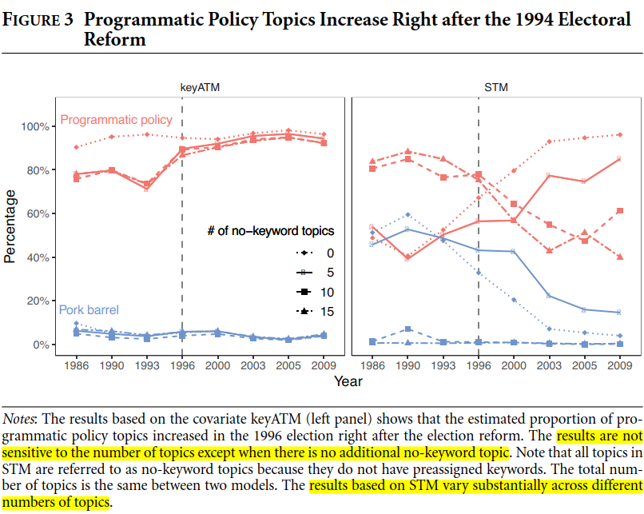

Eshima et al. (2023): 13

# [Tutorial 08](https://htmlpreview.github.io/?https://github.com/czymaracourses/CSS/blob/main/tutorials/FoPra_CSS_tutorial_08.html): Exercises 1.-2.

## Run the Covariate keyATM Model

- Similar to STM, keyATM’s Covariate Model allows topic probabilities to vary over document-level variables
- Exmple: Does Trump Tweet more about Trump?
- Information stored in `tweets_combined$is_trump` (0: Not Trump; 1: Trump)

## Run the Covariate keyATM Model

```r
key_topics_cov <- keyATM(
  docs              = keyATM_docs,
  no_keyword_topics = k-1,
  keywords          = keywords,
  model             = "covariates",
  model_settings    = list(covariates_data    = tweets_combined,
                           covariates_formula = ~ is_trump),
  options           = list(seed = 1337)
  )

covariates_info(key_topics_cov)
```

```
Colnames: (Intercept), is_trumptrump
Standardization: non-factor
Formula: ~ is_trump

Preview:
  (Intercept) is_trumptrump
1           1             0
2           1             0
3           1             0
4           1             0
5           1             0
6           1             0
```

## Estimate Differences

- Examine how topic proportions differ between covariate groups
- Additional step: Estimate the differences based on the keyATM object
- Example: Compare topic proportions for Trump vs. non-Trump tweets

```r
strata_topic <- by_strata_DocTopic(
  key_topics_cov,
  by_var = "is_trumptrump",
  labels = c("Not Trump", "Trump")
  )
```

## Plot the Covariate keyATM Results

- Plot topic proportions across covariate groups

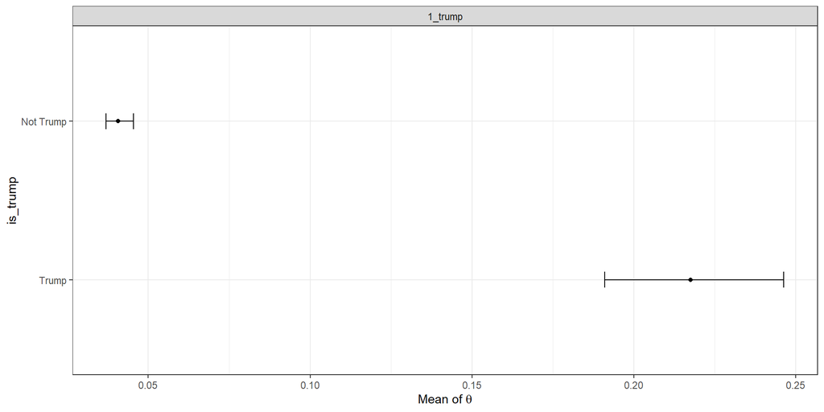

```r
plot(strata_topic, var_name = "is_trump", show_topic = 1)
```

# [Tutorial 08](https://htmlpreview.github.io/?https://github.com/czymaracourses/CSS/blob/main/tutorials/FoPra_CSS_tutorial_08.html): Exercises 3.

# Bidirectional Encoder Representations from Transformers (BERTopic)

## BERTopic Models

- Uses pre-trained transformer-based language models to create word clusters
- Based on class-based Term Frequency - Inverse Document Frequency ([c-TF-IDF](https://maartengr.github.io/BERTopic/algorithm/algorithm.html#5-topic-representation)) scores
- *Which words are typical for topic 1 and not so much for all other topics?*
- Single membership models (each text belongs to only one topic)

## BERTopic Models

- Automatically chooses number of topics, including a garbage topic
- Number of topics can be changed with `nr_topics`, which merges topics *after* they have been created
- Usually little preprocessing as all parts of a document are used for document embeddings (might make sense to remove noise (e.g., HTML-tags))
- At the moment, the `BERTopic` library by [Grootendorst (2023)](https://maartengr.github.io/BERTopic/index.html) is only available in *Python* (not R)
- Some [best practices](https://maartengr.github.io/BERTopic/getting_started/best_practices/best_practices.html) recommended by the author

## BERTopic Models

- BERTopic supports all kinds of topic modeling techniques
- Check out the [documentation](https://maartengr.github.io/BERTopic/getting_started/quickstart/quickstart.html) and the [GitHub repository](https://github.com/MaartenGr/BERTopic) to find the right settings for your case

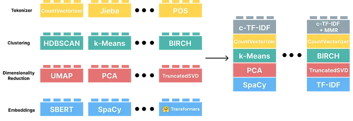

BERTopic models

## Using BERTopic

- Install the library via `pip install bertopic`
- Use pre-trained transformer models (e.g., BERT, RoBERTa)
- Explore customization options, such as setting `nr_topics` to merge similar topics
- Will be applied in session 12 (*Using Google and Amazon Web Services*)

# Summing up

## Deciding on the Right Method

| Criterion | Dictionary | Supervised | Unsupervised | BERTopic |
| --- | --- | --- | --- | --- |
| Supervision level | Predefined keywords or dictionaries | Annotated training data | None | None |
| Preprocessing | High (lemmatization, custom dictionary setup, etc.) | Moderate (text cleaning) | Moderate (text cleaning) | Minimal (often raw text) |
| Flexibility | Completely defined by user-created dictionaries | Depends on training set and classifier | Number of topics and priors | Fine-tuning and priors |
| Computational power | Low to medium | Medium | Medium | High |

## Deciding on the Right Method

- No universal solution: Each method (dictionary, supervised, unsupervised) has unique strengths
- Experiment with different approaches and validate results
- Data-driven choice: Tailor the method to the specific needs of the research question